# Administración de Personal en R

### Objetivos

El Objetivo de esta presentación es mostrar en muy sencillos pasos, un pre-procesamiento de novedades para la liquidación de sueldos.

Siendo el área de Payroll una de las principales de RRHH, nos resultó interesante armar una propuesta que ayude a disminuir el tiempo destinado a la preparación de los datos para la liquidación.

Muchas de las funciones que habitualmente se realizan con Excel, también se pueden hacer con otras herramientas, por ejemplo con R, como lo hicimos en este caso.

Existen ventajas y deventajas, pero en este caso y para los ejemplos que vamos a ver, te vamos a mostrar que son muchos más los beneficios.

Te invitamos a acompañarnos!

[figure not shown]

### Objetivos Especificos

Aprender a usar algunos paquetes para limpiar datos y estructurar información en R para trabajar con datos limpios:

- Cada columna es una variable
- Cada fila es una observación

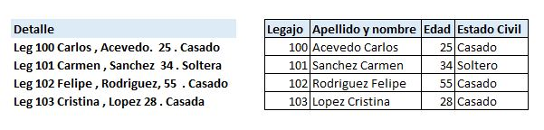

### Destinatarios

El detalle procedimental utilizado en el presente documento, tiene como objetivo que pueda ser utilizado por quienes ya manejan programación en R, pero también por quienes se están iniciando por ese camino.

Para quienes trabajan o conocen la parte *HARD* de HR *(Administración de personal / Payroll)* sentirán familiares los pasos y conceptos.

Para quienes no lo estan, conocerán una alternativa que podría ser implementada en áreas de HR con el fin de agregar valor a la función.

### Aclaraciones

En el presente proyecto no veremos contenido teórico, pueden consultar algunos de los conceptos a trabajar [acá](https://rpubs.com/YanelPaulette/Basicos)

Nos enforcaremos en los pasos y comandos necesarios, de acuerdo a los ejemplos que utilizamos para ejemplificar.

### Procedimiento

A continuación, comenzamos a explicar el paso a paso para realizar la limpieza y organización de los datos, según los objetivos presentados.

Para comenzar, se deben realizar configuraciones iniciales, las cuales iremos detallando a continuación.

Incorporamos las librerias a utilizar.

```r
library(tidyverse)
library(googlesheets4)
library(gargle)
library(funModeling)
library(kableExtra)
library(tm)
library(lubridate)
library(datos)
library( hms)
library(rmdformats)
```

Creamos objetos que vamos a utlizar en diversas oportunidades y solo debemos invocarlos.

```r
blue <- "#344D7E"

fuente <- "Fuente: Elaboración propia"
```

Con el fin de aportar diversidad de análisis y propuestas, vamos a presentar dos ejemplos de procesamiento de novedades.

### Primer Caso

Incorporamos las bases de datos a utilizar. Las mismas las tenemos en el drive:

[figure not shown]

```r
original_1 <- read_sheet("1_AUDkMkG80ribPRl76M2KWtqwDk_hWiM7IOzKSZ6N14") # 1° hoja
egreso_1 <- read_sheet("1_AUDkMkG80ribPRl76M2KWtqwDk_hWiM7IOzKSZ6N14", sheet = "2") #la 2° hoja
```

Almacenamos los datos en objeto para evitar usar la base original.

```r
n1<- original_1
e1<- egreso_1
```

Formateamos nombres de las columnas.

```r
limpios <- make.names(colnames(n1))
colnames(n1) <- limpios
rm(limpios)

limpios <- make.names(colnames(e1))
colnames(e1) <- limpios
rm(limpios)
```

Consultamos el tamaño de nuestro dataset.

```r
dim (n1)
```

```
## [1] 31 17
```

Vemos ahora, si las columnas tienen nombres inadecuados para trabajar. De ser necesario los modificamos.

```r
names(n1)
```

```
##  [1] "Legajo"      "Nombre"      "CC"          "Activo"      "Convenio"
##  [6] "X50."        "X100."       "X100..FT"    "Noc"         "Noc.50."
## [11] "Noc.100."    "Horas.Viaje" "D.Vianda"    "Vianda"      "Desarraigo"
## [16] "Enfermedad"  "Vacaciones"
```

Cambiamos los nombres de las columnas.

```r
n1 <- n1 %>%
  rename("Hs.Extras.50%" = "X50.")%>%
  rename("Hs.Extras.100%" = "X100.")%>%
  rename("Hs.Feriado" = "X100..FT")%>%
  rename("Hs.Noct" = "Noc")%>%
  rename("Hs.Noct.50%" = "Noc.50.")%>%
  rename("Hs.Noct.100%" = "Noc.100.")%>%
  rename("Hs.Viaje" = "Horas.Viaje")%>%
  rename("2°Vianda" = "D.Vianda") %>%
  rename("Centro.Costo" = "CC")
```

Por el alcance del presente proyecto, solo vamos a trabajar con algunas variables, por ello seleccionamos las variables deseadas.

```r
n1<- n1%>%
  select(Legajo, Centro.Costo,  Activo, Convenio, `Hs.Extras.50%`, `Hs.Extras.100%`, Hs.Noct, Enfermedad, Vacaciones )
```

¿ Qué tipo de análisis podemos hacer?

Aqui tenemos que pensar qué datos son relevantes segun el objetivo buscado.

En primer lugar podemos conocer cantidades.

Podemos consultar cual es la nómina que tiene actualmente la compañia mediante la siguiente tabla:

```r
Nomina<- n1 %>%
  select(Activo) %>%
  mutate(cuenta = 1) %>%
  group_by(Activo) %>%
  summarise(Cuenta = sum(cuenta)) %>%
  arrange(-Cuenta)

Nomina
```

```
## # A tibble: 2 x 2
##   Activo Cuenta
##   <chr>   <dbl>
## 1 SI         27
## 2 NO          4
```

Podemos mejorar la visualización.

```r
Nomina$TIP <- c("Podemos destacar algo")

Nomina%>%
  mutate(Cuenta=text_spec(Cuenta, "html", tooltip=TIP)) %>%
    select(Activo,Cuenta) %>% kable("html", escape=F) %>%
    kable_styling(full_width = TRUE, bootstrap_options = c("striped","hover","condensed" )) %>%
row_spec(0, bold=T, color="white", background = blue) %>%
  footnote(general = fuente)
```

| Activo | Cuenta |
| --- | --- |
| SI | 27 |
| NO | 4 |

Note:  
Fuente: Elaboración propia

Ahora veamos de aquellos que son baja, cuales fueron los motivos de egreso.

Es posible que dicha información no la tengamos en la misma tabla, en ese caso, tendremos que hacer unos pasos adicionales.

A continuación vamos a ver cómo relacionamos dos tablas.

Para hacerlo, necesitamos 1 elemento en común: en nuestro caso será el legajo.

El resultado: una nueva tabla con la información combinada.

Primero: consultamos los nombres de las columnas:

```r
names(e1)
```

```
## [1] "Legajo"           "Nombre"           "Fecha.de.Ingreso" "Fecha.de.Egreso"
## [5] "Motivo.de.Egreso"
```

```r
names(n1)
```

```
## [1] "Legajo"         "Centro.Costo"   "Activo"         "Convenio"
## [5] "Hs.Extras.50%"  "Hs.Extras.100%" "Hs.Noct"        "Enfermedad"
## [9] "Vacaciones"
```

Seleccionamos las columnas con las que vamos a trabajar:

```r
e1<- e1%>%
  select(Legajo, Fecha.de.Ingreso, Fecha.de.Egreso, Motivo.de.Egreso)
```

Luego, unimos las tablas por la columna en comun “Legajo” y seleccionamos las columnas deseadas:

```r
e1 <- left_join(n1, e1, by = "Legajo")

e2<-e1%>%
  select(Legajo:Convenio, Motivo.de.Egreso) %>%   # Usamos rangos, y columnas independientes
  filter(Activo=="NO")  %>%
  mutate(cuenta = 1) %>%
  group_by(Motivo.de.Egreso) %>%
  summarise(Cuenta = sum(cuenta)) %>%
  arrange(-Cuenta)
```

Finalmente presentamos la información en una tabla:

```r
e2$TIP <- c("Egresos del mes")

e2%>%
  mutate(Cuenta=text_spec(Cuenta, "html", tooltip=TIP)) %>%
    select(Motivo.de.Egreso,Cuenta) %>% kable("html", escape=F) %>%
    kable_styling(full_width = TRUE, bootstrap_options = c("striped","hover","condensed" )) %>%
row_spec(0, bold=T, color="white", background = blue) %>%
  footnote(general = fuente)
```

| Motivo.de.Egreso | Cuenta |
| --- | --- |
| Desp C/ Causa | 1 |
| Despido con causa | 1 |
| Despido sin C | 1 |
| Renuncia | 1 |

Note:  
Fuente: Elaboración propia

En el cuadro anterior, vemos que los nombres de los motivos de egreso, se repiten, lo cual implica que unifiquemos nombres.

```r
 e2<-  e2 %>%
 mutate(Motivo.de.Egreso = fct_collapse(Motivo.de.Egreso, "Desp C/C" = c("Desp C/ Causa","Despido con causa", "Despido C/C")),
        Motivo.de.Egreso = fct_collapse(Motivo.de.Egreso, "Desp S/C" = c("Despido sin C","Despido sin causa", "Despido S/C")))
```

Ahora si, volvemos a presentar la información en una tabla:

```r
e2 %>%
  mutate(cuenta = 1) %>%
  group_by(Motivo.de.Egreso) %>%
  summarise(Cuenta = sum(cuenta)) %>%
  arrange(-Cuenta)%>%
  kable("html", escape=F) %>%
    kable_styling(full_width = TRUE, bootstrap_options = c("striped","hover","condensed" )) %>%
row_spec(0, bold=T, color="white", background = blue) %>%
  footnote(general = fuente)
```

| Motivo.de.Egreso | Cuenta |
| --- | --- |
| Desp C/C | 2 |
| Desp S/C | 1 |
| Renuncia | 1 |

Note:  
Fuente: Elaboración propia

### Segundo Caso

Ahora veamos otro ejemplo de procesamiento de novedades.

Incorporamos las bases de datos a utilizar.

[figure not shown]

```r
original_2 <- read_sheet("1JOrvsv_C6Kn7tCdaAwqDNJjUC2MEdaZ8Ivj3z6rH3ds", skip=1)
```

Cramos un objeto para manipularlo y evitar usar las bases originales.

```r
n2 <-original_2
```

Consultamos el tamaño de nuestro dataset.

```r
dim (n2)
```

```
## [1] 60 26
```

¿ Qué buscamos con este archivo? Reducirlo a 3 columnas

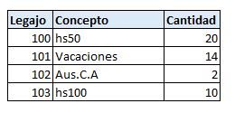

Consultamos las variables

```r
glimpse(n2)
```

```
## Rows: 60
## Columns: 26
## $ `N°Legajo`    <dbl> 11, 31, 134, 152, 158, 167, 173, 183, 190, 205, 217, 220~
## $ Apellido      <chr> "apellido1", "apellido2", "apellido3", "apellido4", "ape~
## $ Nombre        <chr> "nombre1", "nombre2", "nombre3", "nombre4", "nombre5", "~
## $ `Mens / Jorn` <chr> "Mensualizado", "Jornalizado", "Jornalizado", "Jornaliza~
## $ Sector        <chr> "EXTRUSION", "EXTRUSION", "EXTRUSION", "EXTRUSION", "REC~
## $ Sem1          <chr> "09 a 18", "18 a 06", "18 a 06", "06 a 18", "10 a 18", "~
## $ Sem2          <chr> "09 a 18", "18 a 06", "18 a 06", "06 a 18", "10 a 18", "~
## $ Sem3          <chr> "Vac", "18 a 06", "06 a 18", "18 a 06", "10 a 18", "06 a~
## $ Sem4          <chr> "09 a 18", "Vac", "06 a 18", "18 a 06", "10 a 18", "06 a~
## $ Sem5          <chr> "09 a 18", "Vac", "18 a 06", "06 a 18", "Vac", "18 a 06"~
## $ `16/12/2021`  <chr> "Vac", "18 a 06", "06 a 18", "18 a 06", "10 a 18", "06 a~
## $ `17/12/2021`  <chr> "Vac", "Aus c/ aviso", "06 a 18", "18 a 06", "10 a 18", ~
## $ `18/12/2021`  <chr> "Vac", "Vac", "06 a 12", NA, NA, "06 a 12", NA, "06:38 a~
## $ `19/12/2021`  <chr> "Vac", NA, NA, NA, NA, NA, "calent 4 hs", NA, NA, NA, NA~
## $ `20/12/2021`  <chr> "09 a 18", "Vac", "06 a 18", "18 a 06", "10 a 18", "06 a~
## $ `21/12/2021`  <chr> "09 a 18", "Vac", "06 a 18", "18 a 06", "10 a 18", "06 a~
## $ `22/12/2021`  <chr> "09 a 18", "Vac", "06 a 18", "18 a 06", "10 a 18", "06 a~
## $ `23/12/2021`  <chr> "09 a 18", "Vac", "06 a 18", "22 a 06", "10 a 18", "06 a~
## $ `24/12/2021`  <chr> "09 a 14", "Vac", "08:02 a 14", NA, "10 a 14", "06 a 14"~
## $ `25/12/2021`  <chr> NA, "Vac", NA, NA, NA, NA, NA, NA, "Vac", "Vac", NA, NA,~
## $ `26/12/2021`  <chr> NA, "Vac", NA, NA, NA, NA, NA, NA, "Vac", "Vac", NA, NA,~
## $ `27/12/2021`  <chr> "09 a 18", "Vac", "18 a 06", "06 a 18", "Vac", "18 a 06"~
## $ `28/12/2021`  <chr> "09 a 18", "Vac", "18 a 06", "06 a 18", "Vac", "18:40 a ~
## $ `29/12/2021`  <chr> "09 a 18", "Vac", "18 a 06", "06 a 18", "Vac", "18 a 06"~
## $ `30/12/2021`  <chr> "09 a 18", "Vac", "18 a 06", "06 a 18", "Vac", "18 a 06"~
## $ `31/12/2021`  <chr> "09 a 18", "Vac", NA, "06 a 18", "Vac", NA, "Aus s/ avis~
```

Eliminamos columnas que ya sabemos no vamos a usar.

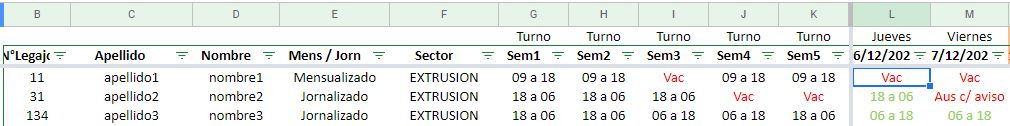

```r
n2<- n2 %>%
  select(everything()) %>%
  select(-Sem1:-Sem5)
```

Pasamos a mayúsculas, por una cuestión visual.

```r
n2 <- mutate_if(n2, is.factor, toupper)
n2 <- mutate_if(n2, is.character, toupper)
```

Hacemos un poco de magia para poder tener nuestra información organizada.

```r
n2<- n2 %>%
  pivot_longer(cols = c(`16/12/2021`:`31/12/2021`), names_to = "Fecha", values_to = "Horario")
```

Trabajar con fechas, no suele ser tarea fácil, pero es neceario para realizar ciertos procesos.

Pasamos a formato “Fecha”, la columna designada.

```r
n2$Fecha <- format(as.Date(n2$Fecha, format = "%d/%m/%Y"), "%m-%d-%Y")

n2 <- n2 %>%
  mutate(Fecha = mdy(Fecha))
n2 <- n2 %>%
mutate(`Dia` = wday(n2$Fecha,label = TRUE, abbr = FALSE))
```

Modificamos las columnas, por una cuestión visual.

```r
limpios <- make.names(colnames(n2))
colnames(n2) <- limpios
rm(limpios)
```

Cambiamos los nombres a las columnas, según los intereses del cliente.

```r
n2 <- n2 %>%
  rename("Legajo" = "N.Legajo")%>%
  rename("Agrupación1" = "Mens...Jorn")%>%
  rename("Agrupación2" = "Sector")
```

```r
n2<- within(n2, 'Apynom' <- paste(Apellido, Apellido, sep=' '))


n2<- n2 %>%
  select('Legajo', 'Apynom',everything()) %>%
  select(-Apellido, -Nombre) %>%
  arrange(Apynom)
```

Limpiamos y ordenamos las licencias.

```r
n2<- n2 %>%
  mutate(Licencia=Horario)%>%
  mutate(Lic=0)


n2<- n2%>%
  mutate(Licencia= str_trim(Licencia,side = "both"),
         Licencia =  fct_collapse(Licencia, "Vacaciones" = "VAC"),
         Licencia =  fct_collapse(Licencia, "Enfermedad" = "ENFERMO"),
         Licencia =  fct_collapse(Licencia, "Aus C/A" = "AUS C/ AVISO"),
         Licencia =  fct_collapse(Licencia, "Aus C/P" = "AUS C/ PERM"),
         Licencia =  fct_collapse(Licencia, "Aus S/A" = "AUS S/ AVISO"),
         Licencia =  fct_collapse(Licencia, "Vacunación" = "VACUNACION"),
         Licencia =  fct_collapse(Licencia, "Domingos" = c("CALENT 4 HS","CALENT 4HS")))

n2<-n2 %>%
mutate(Lic = if_else(Licencia=="Vacaciones"|Licencia=="Enfermedad"|Licencia=="Vacunación"|Licencia=="Aus C/A"|Licencia=="Aus C/P"|Licencia=="Aus S/A"|Licencia=="Domingos", 1 ,0))

n2$Licencia[n2$Lic==0]<-0

n2<- n2%>%
  select(everything(), -Lic)
```

Continuamos con los horarios. Necesitamos limpiarlos, para poder trabajar con las variables.

```r
n2 <- n2 %>%
  mutate%>%
    separate(Horario,c("Entrada","Salida"), sep=" A ",extra="merge",fill="left")

n2$Entrada<-as.numeric(n2$Entrada)
n2$Salida<-as.numeric(n2$Salida)
```

Definimos objetos necesarios, para trabajar con horas extras.

```r
hs_semana_jornal<- 8
hs_sabado_jornal<- 6
```

```r
n2<- n2 %>%
  mutate(
    `cod` = case_when(
       Dia == "domingo" ~ 1,
       Dia == "sábado" ~ 3,
      TRUE ~ 2
    )
  )
```

Parametrizamos las columnas releacionadas con horas extras.

```r
#1=Domingo
#2=Semana
#3=sabado

n2<-n2 %>%
mutate(hs50 = if_else(cod == 2& Salida<Entrada, ((24-Entrada)+(0+Salida))-hs_semana_jornal,(if_else(cod == 2& Entrada<Salida, (Salida-Entrada)-hs_semana_jornal, 0))),
       hs100 =if_else(cod == 1& Salida<Entrada, (24-Entrada)+(0+Salida),(if_else(cod == 1& Entrada<Salida, (Salida-Entrada), 0))))
```

Hacemos lo mismo con horas nocturnas.

```r
n2<-n2 %>%
mutate(Noc = if_else(Salida >21, (Salida-21),
             if_else(Entrada >21,(24-Entrada)+(0+Salida),0)))
```

Si la persona trabaja un feriado, tenemos que considerar dichas horas.

Comenzamos configurando los días feriados.

```r
calendario <- data.frame(
  date = seq(ymd("2021-12-01"), ymd("2021-12-31"), by = 1), evento = 0)


feriados <- c(ymd("2021-12-25"), ymd("2021-12-08"))

calendario[calendario$date %in% feriados, "evento"] <- "Feriado"

calendario <- calendario %>%
  rename("Fecha" = "date")
```

Luego, identificamos los dias feriados de nuestro archivo de trabajo.

```r
n2<-left_join(n2, calendario, by = "Fecha")

n2 <- n2 %>%
  rename("Feriado" = "evento")
```

Por ultimo, si trabajó un feriado, remplazamos las horas trabajadas, en una columna creada a tal efecto.

```r
n2<- n2 %>%
mutate(Feriado = if_else(Feriado == "Feriado" & Entrada>0,Salida-Entrada,0))

#No hay feriados en la base original
n2 %>%
  select(Legajo,Fecha,Feriado)%>%
  filter(Feriado>0)
```

```
## # A tibble: 0 x 3
## # ... with 3 variables: Legajo <dbl>, Fecha <date>, Feriado <dbl>
```

Hacemos un poco de magia para ordenar las licencias.

```r
n2%>%
  select(Licencia) %>%
  mutate(cuenta = 1) %>%
  group_by(Licencia) %>%
  summarise(Cuenta = sum(cuenta)) %>%
  arrange(-Cuenta)
```

```
## # A tibble: 8 x 2
##   Licencia   Cuenta
##   <fct>       <dbl>
## 1 <NA>          777
## 2 Vacaciones    134
## 3 Aus C/A        15
## 4 Enfermedad     15
## 5 Vacunación      8
## 6 Aus S/A         7
## 7 Aus C/P         2
## 8 Domingos        2
```

```r
n2<-n2%>%
 mutate(cuenta = 1)

n2<-n2  %>%
pivot_wider(names_from = Licencia, values_from = cuenta)
```

Mejoramos la visualización de las columnas.

```r
limpios <- make.names(colnames(n2))
colnames(n2) <- limpios
rm(limpios)
```

Ingreso Masivo

Llegamos al final. Una vez que procesamos todo el archivo, necesitamos consolidar todo en solo tres columnas, para luego liquidar las novedades informadas del legajo mediante un sistema de liquidación de sueldos.

El resultado es el siguiente:

```r
n2<-n2 %>%
  pivot_longer(cols = c(`hs50`:`Domingos`), names_to = "concepto", values_to = "cantidad")%>%
    select(Legajo, Apynom,Fecha,  Agrupación1,Agrupación2, concepto, cantidad )%>%
  filter(cantidad>0)%>%
  filter(concepto!='NA.')
```

```r
n2%>%
  select(Legajo, concepto,  cantidad) %>%
  rename("Concepto"= "concepto")%>%
  group_by(Legajo,Concepto) %>%
  summarise(Cantidad = sum(cantidad))
```

```
## # A tibble: 113 x 3
## # Groups:   Legajo [59]
##    Legajo Concepto   Cantidad
##     <dbl> <chr>         <dbl>
##  1     11 hs50              9
##  2     11 Vacaciones        4
##  3     31 Aus.C.A           1
##  4     31 hs50              4
##  5     31 Vacaciones       13
##  6    134 hs50             40
##  7    152 hs50             40
##  8    152 Noc               8
##  9    158 Vacaciones        5
## 10    167 hs50             36
## # ... with 103 more rows
```

Llegamos al final. Gracias por la participación y lxs esperamos en nuestras redes para seguir en contacto!

### Contacto

[Yanel Paulette](https://yanelpaulette.netlify.app/)

[Diego Sipes](https://www.linkedin.com/in/diego-s-51474032//)